# Insights from Failed Orders

Gett, previously known as GetTaxi, is an Israeli-developed technology platform solely focused on corporate Ground Transportation Management (GTM). They have an application where clients can order taxis, and drivers can accept their rides (offers). At the moment, when the client clicks the Order button in the application, the matching system searches for the most relevant drivers and offers them the order. In this task, we would like to investigate some matching metrics for orders that did not completed successfully, i.e., the customer didn't end up getting a car.

GitHub: [Insights From Failed Orders](https://github.com/yashasnadigsyn/Insights-From-Failed-Orders/)

```python
import pandas as pd
import matplotlib.pyplot as plt
import seaborn as sns
import numpy as np
```

```python
data_offers = pd.read_csv("datasets/data_offers.csv")
data_orders = pd.read_csv("datasets/data_orders.csv")
```

```python
data_offers.head()
```

|  | order_gk | offer_id |
| --- | --- | --- |
| 0 | 3000579625629 | 300050936206 |
| 1 | 3000627306450 | 300052064651 |
| 2 | 3000632920686 | 300052408812 |
| 3 | 3000632771725 | 300052393030 |
| 4 | 3000583467642 | 300051001196 |

```python
data_orders.head()
```

|  | order_datetime | origin_longitude | origin_latitude | m_order_eta | order_gk | order_status_key | is_driver_assigned_key | cancellations_time_in_seconds |
| --- | --- | --- | --- | --- | --- | --- | --- | --- |
| 0 | 18:08:07 | -0.978916 | 51.456173 | 60.0 | 3000583041974 | 4 | 1 | 198.0 |
| 1 | 20:57:32 | -0.950385 | 51.456843 | NaN | 3000583116437 | 4 | 0 | 128.0 |
| 2 | 12:07:50 | -0.969520 | 51.455544 | 477.0 | 3000582891479 | 4 | 1 | 46.0 |
| 3 | 13:50:20 | -1.054671 | 51.460544 | 658.0 | 3000582941169 | 4 | 1 | 62.0 |
| 4 | 21:24:45 | -0.967605 | 51.458236 | NaN | 3000583140877 | 9 | 0 | NaN |

```python
data_orders.info()
```

```
<class 'pandas.core.frame.DataFrame'>
RangeIndex: 10716 entries, 0 to 10715
Data columns (total 8 columns):
 #   Column                         Non-Null Count  Dtype
---  ------                         --------------  -----
 0   order_datetime                 10716 non-null  object
 1   origin_longitude               10716 non-null  float64
 2   origin_latitude                10716 non-null  float64
 3   m_order_eta                    2814 non-null   float64
 4   order_gk                       10716 non-null  int64
 5   order_status_key               10716 non-null  int64
 6   is_driver_assigned_key         10716 non-null  int64
 7   cancellations_time_in_seconds  7307 non-null   float64
dtypes: float64(4), int64(3), object(1)
memory usage: 669.9+ KB
```

## Section 1: Distribution of Orders by Reasons for Failure

```python
cancelled_by_client_no_driver = data_orders[(data_orders['order_status_key'] == 4) & (data_orders['is_driver_assigned_key'] == 0)]
print(len(cancelled_by_client_no_driver))
```

```
4496
```

```python
cancelled_by_client_driver = data_orders[(data_orders['order_status_key'] == 4) & (data_orders['is_driver_assigned_key'] == 1)]
print(len(cancelled_by_client_driver))
```

```
2811
```

```python
cancelled_by_system = data_orders[(data_orders['order_status_key'] == 9)]
print(len(cancelled_by_system))
```

```
3409
```

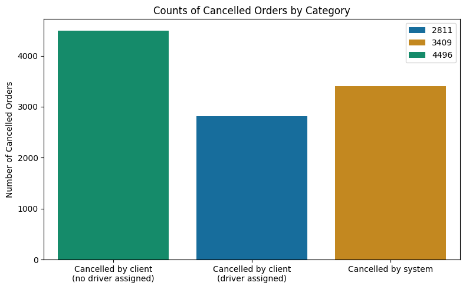

```python
categories = [
    "Cancelled by client\n(no driver assigned)",
    "Cancelled by client\n(driver assigned)",
    "Cancelled by system"
]
counts = [len(cancelled_by_client_no_driver), len(cancelled_by_client_driver), len(cancelled_by_system)]

plt.figure(figsize=(8, 5))
sns.barplot(x=categories, y=counts, hue=counts, palette="colorblind")
plt.ylabel("Number of Cancelled Orders")
plt.title("Counts of Cancelled Orders by Category")
plt.tight_layout()
plt.show()
```

## Analysis

- The largest category of failures is 'Clients cancelling before a driver is assigned'.
- There is a potential issue with long wait times or high initial ETAs, causing customer impatience.
- The second largest is 'System Rejects', shows a driver supply problem.

## Section 2: How do failed orders change throughout the day?

```python
order_data_by_hour = data_orders[['order_datetime', 'order_status_key', 'is_driver_assigned_key']].copy()
order_data_by_hour['order_datetime'] = pd.to_datetime(order_data_by_hour['order_datetime'])
order_data_by_hour['hour'] = order_data_by_hour['order_datetime'].dt.hour
```

```python
order_data_by_hour.head()
```

|  | order_datetime | order_status_key | is_driver_assigned_key | hour |
| --- | --- | --- | --- | --- |
| 0 | 2025-07-04 18:08:07 | 4 | 1 | 18 |
| 1 | 2025-07-04 20:57:32 | 4 | 0 | 20 |
| 2 | 2025-07-04 12:07:50 | 4 | 1 | 12 |
| 3 | 2025-07-04 13:50:20 | 4 | 1 | 13 |
| 4 | 2025-07-04 21:24:45 | 9 | 0 | 21 |

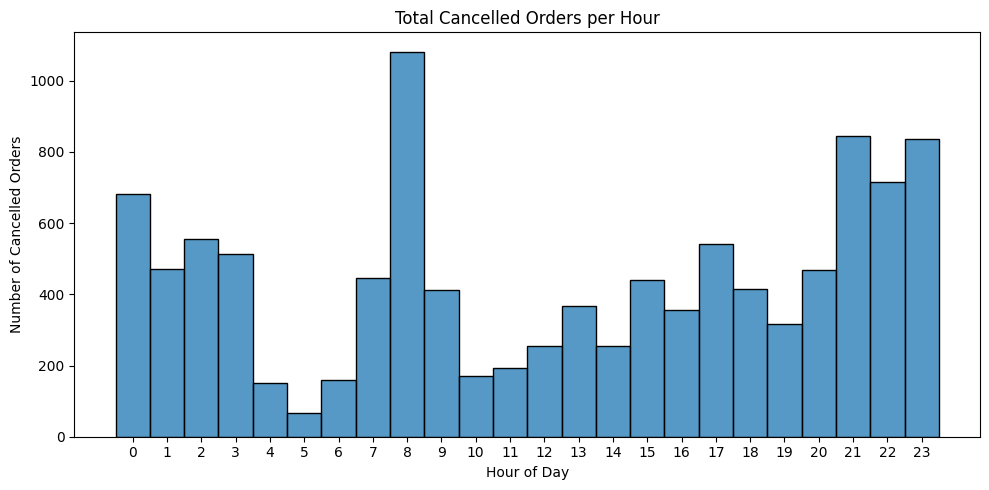

```python
plt.figure(figsize=(10,5))
sns.histplot(order_data_by_hour, x='hour', discrete=True)
plt.xticks(range(24))
plt.title("Total Cancelled Orders per Hour")
plt.xlabel("Hour of Day")
plt.ylabel("Number of Cancelled Orders")
plt.tight_layout()
plt.show()
```

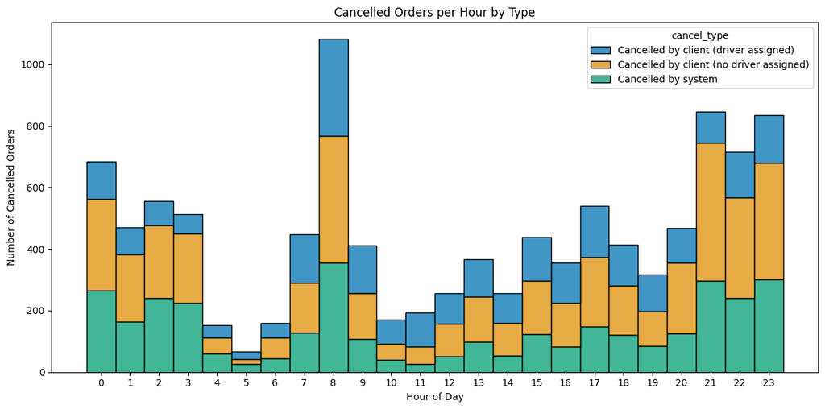

```python
def cancellation_type(row):
    if row['order_status_key'] == 4 and row['is_driver_assigned_key'] == 1:
        return 'Cancelled by client (driver assigned)'
    elif row['order_status_key'] == 4 and row['is_driver_assigned_key'] == 0:
        return 'Cancelled by client (no driver assigned)'
    elif row['order_status_key'] == 9:
        return 'Cancelled by system'
    else:
        return None

order_data_by_hour['cancel_type'] = order_data_by_hour.apply(cancellation_type, axis=1)
filtered = order_data_by_hour[order_data_by_hour['cancel_type'].notnull()]

plt.figure(figsize=(12,6))
sns.histplot(data=filtered, x='hour', hue='cancel_type', multiple='stack', discrete=True, palette='colorblind')
plt.xticks(range(24))
plt.title("Cancelled Orders per Hour by Type")
plt.xlabel("Hour of Day")
plt.ylabel("Number of Cancelled Orders")
plt.tight_layout()
plt.show()
```

## Analysis

- Cancels are very high during 8 in the morning by both client and system.
- Surprisingly, not much cancelled orders during evening rush hours - 5 P.M. to 8 P.M.

## Section 3: How long are customers waiting before they cancel?

```python
data_orders_cancellation = data_orders[['order_datetime', 'is_driver_assigned_key', 'cancellations_time_in_seconds']].copy()
data_orders_cancellation['order_datetime'] = pd.to_datetime(data_orders_cancellation['order_datetime'])
data_orders_cancellation['hour'] = data_orders_cancellation['order_datetime'].dt.hour
```

```python
data_orders_cancellation.info()
```

```
<class 'pandas.core.frame.DataFrame'>
RangeIndex: 10716 entries, 0 to 10715
Data columns (total 4 columns):
 #   Column                         Non-Null Count  Dtype
---  ------                         --------------  -----
 0   order_datetime                 10716 non-null  datetime64[ns]
 1   is_driver_assigned_key         10716 non-null  int64
 2   cancellations_time_in_seconds  7307 non-null   float64
 3   hour                           10716 non-null  int32
dtypes: datetime64[ns](1), float64(1), int32(1), int64(1)
memory usage: 293.1 KB
```

```python
data_orders_cancellation = data_orders_cancellation.dropna()
```

```python
data_orders_cancellation.info()
```

```
<class 'pandas.core.frame.DataFrame'>
Index: 7307 entries, 0 to 10715
Data columns (total 4 columns):
 #   Column                         Non-Null Count  Dtype
---  ------                         --------------  -----
 0   order_datetime                 7307 non-null   datetime64[ns]
 1   is_driver_assigned_key         7307 non-null   int64
 2   cancellations_time_in_seconds  7307 non-null   float64
 3   hour                           7307 non-null   int32
dtypes: datetime64[ns](1), float64(1), int32(1), int64(1)
memory usage: 256.9 KB
```

```python
Q1 = data_orders_cancellation['cancellations_time_in_seconds'].quantile(0.25)
Q3 = data_orders_cancellation['cancellations_time_in_seconds'].quantile(0.75)
IQR = Q3 - Q1

lower_bound = Q1 - 1.5 * IQR
upper_bound = Q3 + 1.5 * IQR
```

```python
outliers = data_orders_cancellation[
    (data_orders_cancellation['cancellations_time_in_seconds'] < lower_bound) |
    (data_orders_cancellation['cancellations_time_in_seconds'] > upper_bound)
]

print(f"Number of outliers: {len(outliers)}")
```

```
Number of outliers: 592
```

```python
data_orders_cancellation_no_outliers = data_orders_cancellation[
    (data_orders_cancellation['cancellations_time_in_seconds'] >= lower_bound) &
    (data_orders_cancellation['cancellations_time_in_seconds'] <= upper_bound)
]
print(f"Rows after removing outliers: {len(data_orders_cancellation_no_outliers)}")
```

```
Rows after removing outliers: 6715
```

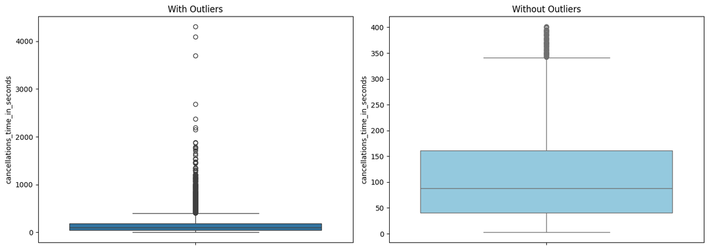

```python
fig, axes = plt.subplots(1, 2, figsize=(14, 5))

# With outliers
sns.boxplot(ax=axes[0], data=data_orders_cancellation, y='cancellations_time_in_seconds')
axes[0].set_title("With Outliers")

# Without outliers
sns.boxplot(ax=axes[1], data=data_orders_cancellation_no_outliers, y='cancellations_time_in_seconds', color='skyblue')
axes[1].set_title("Without Outliers")

plt.tight_layout()
plt.show()
```

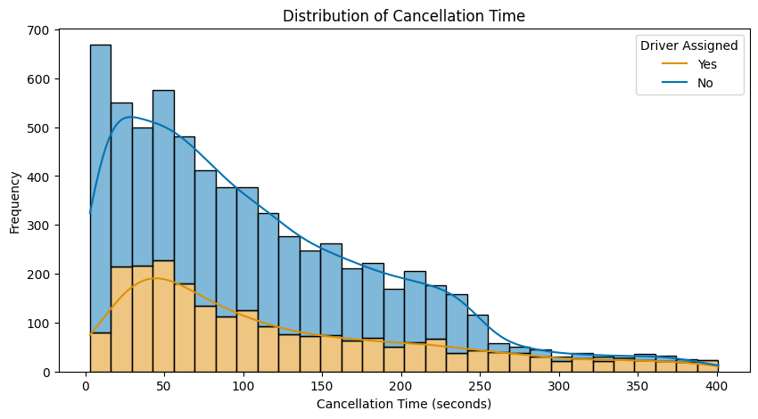

```python
plt.figure(figsize=(10, 5))
ax = sns.histplot(
    data=data_orders_cancellation_no_outliers,
    x='cancellations_time_in_seconds',
    hue='is_driver_assigned_key',
    multiple='stack',
    bins=30,
    kde=True,
    palette='colorblind'
)

plt.title("Distribution of Cancellation Time")
plt.xlabel("Cancellation Time (seconds)")
plt.ylabel("Frequency")
plt.legend(title='Driver Assigned', labels=['Yes', 'No'])
plt.show()
```

```python
avg_time_to_cancel = data_orders_cancellation_no_outliers.groupby('is_driver_assigned_key').mean()
```

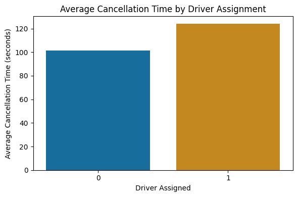

```python
avg_time_df = avg_time_to_cancel.reset_index()

plt.figure(figsize=(6, 4))
sns.barplot(
    data=avg_time_df,
    x='is_driver_assigned_key',
    y='cancellations_time_in_seconds',
    palette='colorblind'
)
plt.title('Average Cancellation Time by Driver Assignment')
plt.xlabel('Driver Assigned')
plt.ylabel('Average Cancellation Time (seconds)')
plt.tight_layout()
plt.show()
```

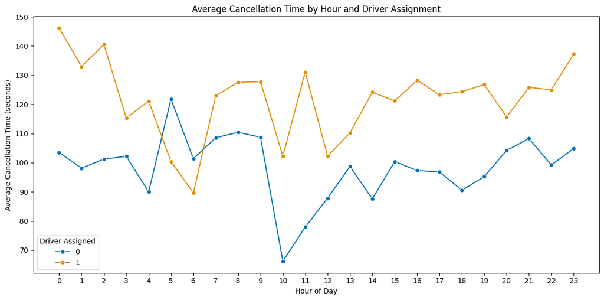

```python
# Group by hour and driver assignment, then calculate mean cancellation time
avg_cancel_time_by_hour = data_orders_cancellation_no_outliers.groupby(
    ['hour', 'is_driver_assigned_key']
)['cancellations_time_in_seconds'].mean().reset_index()

plt.figure(figsize=(12,6))
sns.lineplot(
    data=avg_cancel_time_by_hour,
    x='hour',
    y='cancellations_time_in_seconds',
    hue='is_driver_assigned_key',
    marker='o',
    palette='colorblind'
)
plt.title('Average Cancellation Time by Hour and Driver Assignment')
plt.xlabel('Hour of Day')
plt.ylabel('Average Cancellation Time (seconds)')
plt.xticks(range(24))
plt.legend(title='Driver Assigned')
plt.tight_layout()
plt.show()
```

## Analysis

- So, many people are cancelling within 20 seconds of trying to book a taxi without waiting for driver
- More than 400 cancelled orders during 9 P.M.

## Section 4: What do the Estimated Times of Arrival (ETAs) look like by hour?

```python
data_orders_eta = data_orders[data_orders['is_driver_assigned_key'] == 1]
```

```python
data_orders_eta = data_orders_eta[['order_datetime', 'm_order_eta']]
```

```python
data_orders_eta.info()
```

```
<class 'pandas.core.frame.DataFrame'>
Index: 2814 entries, 0 to 10715
Data columns (total 2 columns):
 #   Column          Non-Null Count  Dtype
---  ------          --------------  -----
 0   order_datetime  2814 non-null   object
 1   m_order_eta     2814 non-null   float64
dtypes: float64(1), object(1)
memory usage: 66.0+ KB
```

```python
data_orders_eta['order_datetime'] = pd.to_datetime(data_orders_eta['order_datetime'])
data_orders_eta['hour'] = data_orders_eta['order_datetime'].dt.hour
```

```python
data_orders_eta.info()
```

```
<class 'pandas.core.frame.DataFrame'>
Index: 2814 entries, 0 to 10715
Data columns (total 3 columns):
 #   Column          Non-Null Count  Dtype
---  ------          --------------  -----
 0   order_datetime  2814 non-null   datetime64[ns]
 1   m_order_eta     2814 non-null   float64
 2   hour            2814 non-null   int32
dtypes: datetime64[ns](1), float64(1), int32(1)
memory usage: 76.9 KB
```

```python
avg_data_order_eta = data_orders_eta.groupby('hour')['m_order_eta'].mean().reset_index()
avg_data_order_eta.head()
```

|  | hour | m_order_eta |
| --- | --- | --- |
| 0 | 0 | 357.959016 |
| 1 | 1 | 324.750000 |
| 2 | 2 | 391.012821 |
| 3 | 3 | 388.093750 |
| 4 | 4 | 299.658537 |

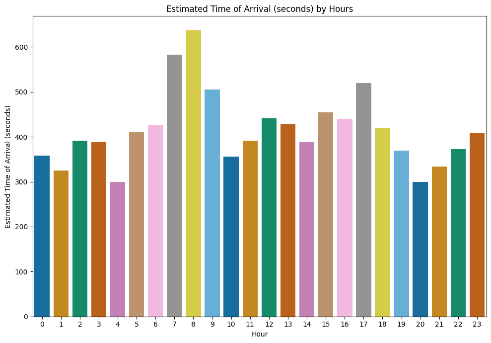

```python
plt.figure(figsize=(10,7))
sns.barplot(data=avg_data_order_eta, x='hour', y='m_order_eta', palette='colorblind')
plt.title('Estimated Time of Arrival (seconds) by Hours')
plt.xlabel('Hour')
plt.ylabel('Estimated Time of Arrival (seconds)')
plt.tight_layout()
plt.show()
```

## Analysis

- The average ETA peaks dramatically at 8 AM, reaching over 10 minutes.
- Also, a clear explanation for the spike in cancellations, as long wait times directly lead to customer frustration and a higher rate of failed orders.

## Section 5: Where are the failure hotspots?

```python
import h3, folium
```

```python
H3_RESOLUTION = 8

data_orders['hex_id'] = data_orders.apply(
    lambda row: h3.latlng_to_cell(row['origin_latitude'], row['origin_longitude'], H3_RESOLUTION),
    axis=1
)
```

```python
data_orders.head()
```

|  | order_datetime | origin_longitude | origin_latitude | m_order_eta | order_gk | order_status_key | is_driver_assigned_key | cancellations_time_in_seconds | hex_id |
| --- | --- | --- | --- | --- | --- | --- | --- | --- | --- |
| 0 | 18:08:07 | -0.978916 | 51.456173 | 60.0 | 3000583041974 | 4 | 1 | 198.0 | 88195d2b03fffff |
| 1 | 20:57:32 | -0.950385 | 51.456843 | NaN | 3000583116437 | 4 | 0 | 128.0 | 88195d2b19fffff |
| 2 | 12:07:50 | -0.969520 | 51.455544 | 477.0 | 3000582891479 | 4 | 1 | 46.0 | 88195d2b1dfffff |
| 3 | 13:50:20 | -1.054671 | 51.460544 | 658.0 | 3000582941169 | 4 | 1 | 62.0 | 88195d7497fffff |
| 4 | 21:24:45 | -0.967605 | 51.458236 | NaN | 3000583140877 | 9 | 0 | NaN | 88195d2b1dfffff |

```python
hex_total_orders = data_orders.groupby('hex_id').size().reset_index(name='total_orders')

failed_orders = data_orders[data_orders['order_status_key'].isin([4, 9])]
hex_failed_orders = failed_orders.groupby('hex_id').size().reset_index(name='fail_count')
```

```python
hex_data = pd.merge(hex_total_orders, hex_failed_orders, on='hex_id', how='left')
hex_data['fail_count'] = hex_data['fail_count'].fillna(0).astype(int)
```

```python
hex_data_sorted = hex_data.sort_values(by='total_orders', ascending=False)
eighty_percent_target = data_orders.shape[0] * 0.80
```

```python
hex_data_sorted['cumulative_orders'] = hex_data_sorted['total_orders'].cumsum()
cutoff_index = hex_data_sorted[hex_data_sorted['cumulative_orders'] >= eighty_percent_target].index[0]
top_hexes = hex_data_sorted.loc[:cutoff_index]
```

```python
num_top_hexes = len(top_hexes)
print(f"Number of size 8 hexes containing 80% of all orders: {num_top_hexes}")
```

```
Number of size 8 hexes containing 80% of all orders: 24
```

```python
map_center = [data_orders['origin_latitude'].mean(), data_orders['origin_longitude'].mean()]
m = folium.Map(location=map_center, zoom_start=12, tiles='cartodbpositron')

for index, row in top_hexes.iterrows():
    hex_id = row['hex_id']
    fail_count = row['fail_count']
    total_orders = row['total_orders']


    geo_boundary = h3.cell_to_boundary(hex_id)
    boundary_tuples = [(lat, lon) for lat, lon in geo_boundary]

    if fail_count > 150:
        color = '#d73027'
    elif fail_count > 75:
        color = '#fdae61'
    elif fail_count > 25:
        color = '#fee090'
    else:
        color = '#abd9e9'

    folium.Polygon(
        locations=boundary_tuples,
        color="black",
        weight=1,
        fill_color=color,
        fill_opacity=0.7,
        tooltip=f"Hex ID: {hex_id}<br>Failed Orders: {fail_count}<br>Total Orders: {total_orders}"
    ).add_to(m)

map_filename = 'failure_hotspot_map.html'
m.save(map_filename)
```

## Analysis

- Just 24 size-8 hexagons account for 80% of all failed orders, highlighting extreme geographic concentration.
- Below map shows the areas which have many failed orders.

```python
from IPython.display import IFrame

IFrame(src='failure_hotspot_map.html', width=700, height=600)
```

[interactive chart not shown]